# RStudio server instructions

# RStudio Server Instructions

## Overview

The DEAC Cluster is the high-performance computing (HPC) cluster at Wake Forest. The cluster has a lot of useful software pre-installed, including R (with many important packages) and C++. As getting C++, Rcpp, and RcppArmadillo working on your personal computer can be quite difficult (particularly for Macs), in this course we will use the DEAC Cluster to do work that involves C++ in R.

One of the cool things that the cluster provides, through DEAC OnDemand, is the ability to connect to the cluster in your browser and open interactive RStudio sessions. This will allow you to use R and RStudio remotely in a very similar way to how you use them locally, while also providing the additional software we need.

## Connecting to the server

Our class has its own site on the DEAC OnDemand cluster at the following url:

https://sta379.deac.wfu.edu/

To get started, click on the link and log in with your usual WFU credentials.

**Note:** Connecting requires you to be on campus WiFi. If you are off-campus, first connect via VPN; see the [VPN overview](https://is.wfu.edu/vpn/) and [installation instructions](https://is.wfu.edu/software/wfu-vpn/) from Information Systems.

Once you log on, you will see the STA 379/679 course homepage, with links to RStudio and VS Code at the bottom (you can ignore VS Code, although you are certainly welcome to use it if you like):

[figure not shown]

## Starting an RStudio session

Click on the RStudio app at the bottom of the course homepage. Before opening RStudio, you will be taken to a page in which you will configure details for the RStudio session.

### Working directory and slurm

At the top of the page, you will enter information about the working directory, slurm account, and slurm partition that you want to use for the session:

**Working directory:** For the working directory, use `/deac/sta/classes/sta379/USERNAME`, replacing `USERNAME` with your Wake Forest username (e.g., my path would be `/deac/sta/classes/sta379/evansc`)

**Slurm account:** Select `sta379` from the drop-down menu

**Slurm partition:** Select `ondemand` from the drop-down menu

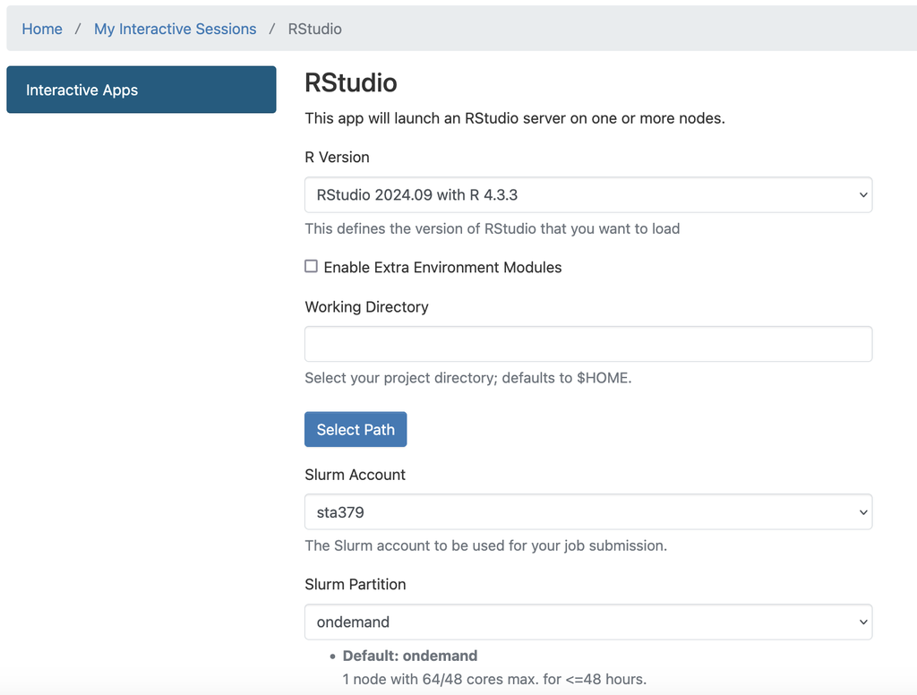

### Resource request

Below, you will then need to specify how much resources you want for your RStudio session.

*This step is very important!* The DEAC cluster does not have infinite resources, and the DEAC team are kindly allowing us to use the cluster for our course. The settings you enter in this configuration page specify how much of the cluster resources you are going to **request** for your RStudio session.

There are three types of resources to specify: *time*, *cores*, and *memory*. To be respectful of other users, **never request more resources than you need**. Follow these rules when requesting resources for our course:

- **Hours:** For in-class work (practice questions, working on HW during class time, etc.), request **1 hour**. For work outside of class, do not request more than **3-4 hours** at once, and request less if you know you will be working for less time. You can always save your work and start a new session if you end up working for longer!
- **Cores:** For this class, **1 core** should generally be sufficient. Unless explicitly instructed, never request more than 2 cores in our class.
- **Memory:** For this class, **8 GB** should generally be sufficient. Unless explicitly instructed, do not request more than 16 GB.

A standard request will look like this, with 1 hour, 1 core, and 8 GB requested (always use node type = Any):

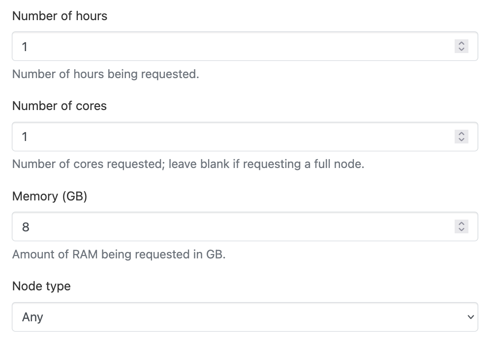

Once you have configured the session correctly, submit the request at the bottom of the page.

### Connecting to the server

Once you have submitted your session request, the request will be **queued** on the cluster. When there are available resources and it is your turn in the queue, the session will be ready to start (generally this should only take a minute), and you will see the following page:

[figure not shown]

This page tells you that you have a session running, provides some details about the session, and tells you how much time is left. To enter the session and open RStudio, click the `Connect to RStudio Server` button. This should open RStudio in a new tab in your browser.

## File management

Your session should be initialized in the working directory `/deac/sta/classes/sta379/USERNAME` on the cluster. This working directory is a folder which will store all of the classwork you do on the DEAC cluster for this course. In the `Files` pane of RStudio, you should see a list of files in your working directory (if this is the first time logging on, the directory may still be empty).

Most of the coding work you do in this course will be submitted through GitHub (see the next section), so typically you shouldn’t need to move files between the RStudio Server and your local computer. If you do, however, then you can **upload** files with the `Upload` button on the files tab:

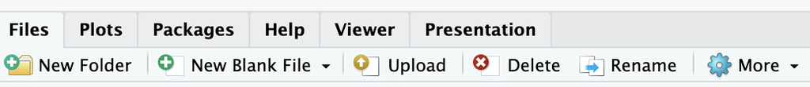

To download files, select the files you want to download (click the checkbox next to them in the file list), then click on `More` -> `Export...`

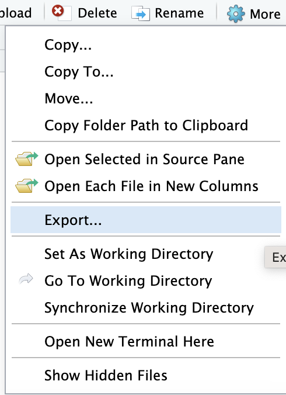

## GitHub

You will use GitHub through RStudio in a similar way as you do on your local computer (same workflow of creating a new project to clone the remote repository, making changes, committing and pushing).

However, you will need to connect to GitHub slightly differently.

### Connecting to GitHub: SSH method setup

If you followed the instructions from [Happy Git and GitHub for the useR](https://happygitwithr.com/), you probably created a Personal Access Token and followed the steps described in Chapter 9 of the book. It is still possible to connect with your PAT on the RStudio Server; however, the server *will not* store your token, so you would need to re-enter the PAT every time you want to interact with GitHub (every clone, pull, and push).

This will get tedious, plus it requires you to have easy access to your saved PAT at all times. Instead, we will use the SSH approach described in [Chapter 10](https://happygitwithr.com/ssh-keys), which works better for the server.

In particular, complete the following steps (more details and explanations can be found in Chapter 10). Throughout, note that the DEAC cluster is a **Linux** server, so whenever OS matters, we need to look at the Linux-specific instructions.

#### Step 1: Log in to the RStudio Server

If you are not already logged in, follow the instructions above to create and open a new session. Remember to limit the resources you request!

#### Step 2: Create the SSH key

In the RStudio server, go to *Tools* -> *Global Options* -> *Git/SVN*:

[figure not shown]

Under *Git executable* it should say `/usr/bin/git`, and it should be empty `(None)` under *SSH key*.

Click the `Create SSH key` button. In the pop-up window, make sure SSH key type is ED25519. Do not change the file path for the SSH key, and you can ignore the passphrase boxes. Your key name will look something like `id_ed25519`.

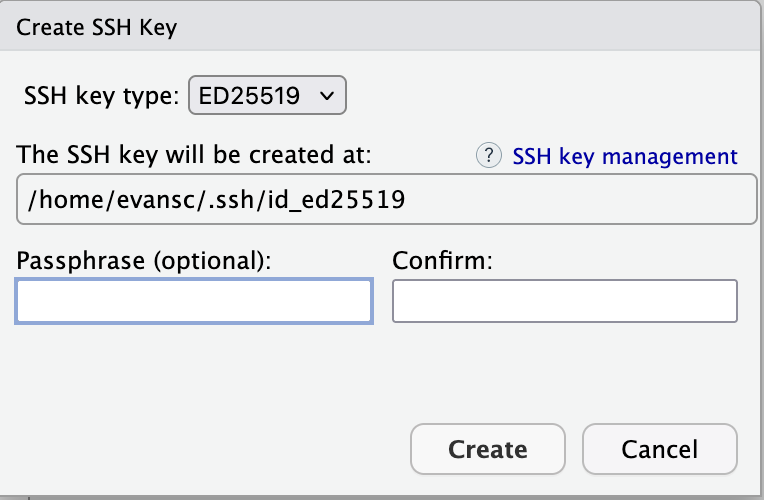

Click `Create`.

#### Step 3: Terminal

Go to the *Terminal* tab in RStudio (should be right next to the *Console* tab):

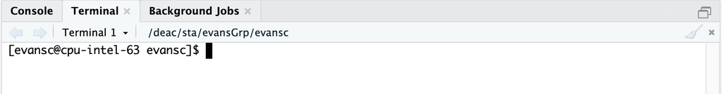

In the terminal, type the following and hit enter:

`eval "$(ssh-agent -s)"`

If the results is something like `Agent pid 15360` (the actual number will vary), then the ssh-agent is enabled. Then, add your key by running the following in the terminal:

`ssh-add ~/.ssh/id_ed25519`

(If your key name is different, replace it with the correct name here).

#### Step 4: Provide the public key to GitHub

In RStudio, go back to *Tools* -> *Global Options* -> *Git/SVN*. Your SSH key should now be filled in. Click on `View public key`, and copy the public key to your clipboard.

Now add the public key to GitHub, following the instructions in [Chapter 10.5.3](https://happygitwithr.com/ssh-keys#on-github). Give it a name like “DEAC OnDemand server”.

You should now be able to interact remotely with GitHub, pulling and pushing like normal. The first time that you try to interact with GitHub using the key, you may get a message asking you to trust the GitHub host. You can type “yes” in that box and continue.

### Using the SSH method when cloning repositories

To clone a GitHub repository to your account on the RStudio Server, the steps will be quite similar to the procedure described in the [GitHub instructions](https://sta379-s25.github.io/resources/github_instructions/#step-5-clone-the-repository-to-your-local-computer) on the course website. There are just a couple changes.

First, you will use SSH rather than HTTPS to clone. Click on the SSH tab instead, and copy the resulting url to your clipboard:

[figure not shown]

On the RStudio Server, create a new project (*File* -> *New Project* -> *Version Control* -> *Git*).

- For the repository URL, paste the SSH url from GitHub.
- Under “create project as a subdirectory of”, choose your working directory for this course (`/deac/sta/classes/sta379/USERNAME`). If you need to change the file path here, click *Browse*, then click the `...` button that appears in the top right of the pop-up window and enter the desired working directory

[figure not shown]

Click *Create Project*

## Saving your work and finishing the session

When you are done working for the time being (note: I do not mean finished with the assignment, I just mean that you are pausing active work on the assignment), it is very important that you save your work before quitting the session.

Do the following:

1. Save any files you have changed
2. If working on an assignment from GitHub:
   - Stage any files changed since the last commit
   - Commit any changes
   - Push to GitHub
3. Once everything is saved, committed, and pushed, close the RStudio Server window in your browser
4. Back on the class dashboard, your *Interactive Sessions* page should still show the current RStudio session. Click the red *Cancel* button, and click *OK* to confirm.

Cancelling our sessions when we stop using them is very important, because it gives the resources we requested back to the DEAC cluster! Do not leave a session running if you are not using it, regardless of how much time is left on the session.